# Week 8 assignment: NLP on social media data

Take our social media we collected last week and:

- extract the sentiment scores of the titles of the posts
  - you can use the keyword method, Python packages, or other methods to extract the sentiment scores
- plot a histogram of the sentiment scores
- look at descriptive statistics (mean, median, standard deviation) of the sentiment scores
- examine the text for some of the highest and lowest sentiment scores
- write a short analysis of the results and our process, as well as propose one idea for something we could use this data for

Optional advanced challenges:

- Compare different sentiment analysis methods (e.g. textblob and VADER). Does one seem to work better than another?
- Get the sentiments of the comments for each post. We can do a lot with this, such as:
  - look at the average sentiment for each post and compare it with the sentiment of the title and/or text
  - look at the distribution of sentiments for each post and find the posts with the widest range of sentiments (controversial posts)
- Examine the subjectivity of our data (e.g. using textblob)
- Use topic modeling on the posts
  - you can also add in the comments to the topic model
- Look at the most frequent words for positive and negative sentiment posts

Note: There is no assignment solution file for this week.

```python
import sqlite3
import pandas as pd
```

```python
con = sqlite3.connect('SJSU_reddit.sqlite')
df = pd.read_sql_query('SELECT * from posts;', con)
con.close()
df
```

|  | title | link | author | n_comments | score | text |
| --- | --- | --- | --- | --- | --- | --- |
| 0 | Hello C'O 2025 / Transfer / Graduate / Prospec... | /r/SJSU/comments/m06ds0/hello_co_2025_transfer... | NoodlesMercury | 12 | 55 | &#x200B;\n\n[Welcome to San Jose State Univers... |
| 1 | CAMPUS BUILDING ACCESS AND TOWER CARDS | /r/SJSU/comments/q3ggay/campus_building_access... | ThePleb420 | 1 | 12 | Hello Spartans,\n\n**Starting October 4, 2021,... |
| 2 | TRANSFERS FALL 2022 CHECK YOUR PORTAL THEY REL... | /r/SJSU/comments/t3yd23/transfers_fall_2022_ch... | dablackpantha | 48 | 21 | I JUST GOT IN |
| 3 | It says I have conditional admission. How do I... | /r/SJSU/comments/t41pzc/it_says_i_have_conditi... | noyesnoyesyesnoyes | 7 | 3 | I can't tell if I got into my main major or se... |
| 4 | View Fall 2022 Transfer Impaction Results | /r/SJSU/comments/t43ghz/view_fall_2022_transfe... | Olanis7820 | 4 | 2 |  |
| ... | ... | ... | ... | ... | ... | ... |
| 945 | To all spring transfers - when did you get you... | /r/SJSU/comments/ptj6kt/to_all_spring_transfer... | One-Veterinarian8059 | 2 | 5 |  |
| 946 | I think I might be sick, and midterm season is... | /r/SJSU/comments/ptgnks/i_think_i_might_be_sic... | ItzN0tMe | 6 | 6 | How do I approach this? Im worried that many p... |
| 947 | Any reputable body shop's avaliable for repair? | /r/SJSU/comments/ptfzel/any_reputable_body_sho... | TheJuice712 | 5 | 5 | New to San Jose, never been here before.\n\nI ... |
| 948 | I feel like switching out of engineering | /r/SJSU/comments/pt0mf2/i_feel_like_switching_... | Banananickle | 14 | 11 | Right now, it sounds really silly but I am in ... |
| 949 | I miss the ivy on Tower Hall | /r/SJSU/comments/pslq2x/i_miss_the_ivy_on_towe... | Fetty_is_the_best | 10 | 114 |  |

950 rows × 6 columns

# Keyword sentiment

```python
sentiment_df = pd.read_csv('AFINN-en-165.txt', sep='\t', names=['word', 'score'], index_col='word')
```

```python
sentiment_df
```

| word | score |
| --- | --- |
| abandon | -2 |
| abandoned | -2 |
| abandons | -2 |
| abducted | -2 |
| abduction | -2 |
| ... | ... |
| yucky | -2 |
| yummy | 3 |
| zealot | -2 |
| zealots | -2 |
| zealous | 2 |

3382 rows × 1 columns

```python
sentiment_dict = sentiment_df.to_dict()['score']
```

```python
import numpy as np

title_sentiments = []
for title in df['title']:
    words = title.lower().split()
    this_titles_sentiments = []
    for w in words:
        if w in sentiment_dict.keys():
            this_titles_sentiments.append(sentiment_dict[w])
        else:
            this_titles_sentiments.append(0)


    title_sentiments.append(np.mean(this_titles_sentiments))
```

```python
df['keyword_sentiment'] = title_sentiments
```

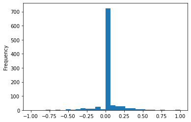

```python
df['keyword_sentiment'].plot.hist(bins=30)
```

```python
df['keyword_sentiment'].mean()
```

```
0.014861030578716718
```

```python
df.sort_values(by='keyword_sentiment')[['title', 'keyword_sentiment']]
```

|  | title | keyword_sentiment |
| --- | --- | --- |
| 212 | Missing Wallet | -1.000000 |
| 204 | I made a stupid mistake | -0.800000 |
| 918 | losing my mind ❤️ | -0.750000 |
| 776 | Failing current semester | -0.666667 |
| 430 | Failing a class | -0.666667 |
| ... | ... | ... |
| 32 | Any good food spots? | 0.750000 |
| 173 | Super smash Bros ultimate | 0.750000 |
| 224 | Minor not awarded | 1.000000 |
| 559 | Job Opportunity | 1.000000 |
| 75 | CARES act? | 1.000000 |

950 rows × 2 columns

```python
df.sort_values(by='keyword_sentiment')['title'].to_list()[:10]
```

```
['Missing Wallet',
 'I made a stupid mistake',
 'losing my mind ❤️',
 'Failing current semester',
 'Failing a class',
 'Missed tuition deadlin',
 'Update: Missing Wallet',
 'San Jose State University President Mary Papazian to resign amid sexual abuse scandal',
 'UC Davis Student Walkout',
 'MISSED FALL GRADUATION DEADLINE']
```

```python
df.sort_values(by='keyword_sentiment', ascending=False)['title'].to_list()[:10]
```

```
['Job Opportunity',
 'CARES act?',
 'Minor not awarded',
 'Super smash Bros ultimate',
 'Any good food spots?',
 'SJSU application help',
 'MBA Course Help',
 'Fun stuff to do near campus',
 'SJSU baseball opens season with 14-9 win',
 'Students with ADHD? Join our research study to win $40 Amazon gift card!']
```

# Using Python packages for sentiment analysis

```python
conda install -c conda-forge textblob vadersentiment -y
```

```
Solving environment: done

# All requested packages already installed.
```

```python
from textblob import TextBlob

tb = TextBlob("Any reputable body shop's avaliable for repair?")
tb.sentiment
```

```
Sentiment(polarity=0.5, subjectivity=0.8)
```

```python
def get_tb_sentiment(text):
    tb = TextBlob(text)
    return tb.sentiment[0]

df['tb_sentiment'] = df['title'].apply(get_tb_sentiment)
```

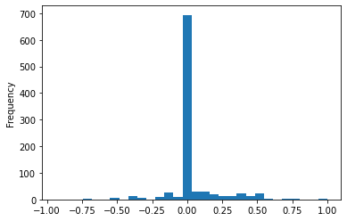

```python
df['tb_sentiment'].plot.hist(bins=30)
```

```python
df['tb_sentiment'].mean()
```

```
0.036635448469659
```

```python
from vaderSentiment.vaderSentiment import SentimentIntensityAnalyzer

analyzer = SentimentIntensityAnalyzer()
analyzer.polarity_scores("Any reputable body shop's avaliable for repair?")
```

```
{'neg': 0.0, 'neu': 1.0, 'pos': 0.0, 'compound': 0.0}
```

```python
analyzer.polarity_scores("Any reputable body shop's avaliable for repair?")['compound']
```

```
0.0
```

# Summary

This assignment was helpful in understanding the sentiment analysis.We loaded the data from prior week.We then imported the text file provided in Jupyter notebook.We then performed sentiment analysis and got mean score of 0.014.After that by using the list function for titles we listed out the top and bottom sentiments. We then imported tectblob to perform further analysis.We recieved polarity and subjectivity score of 0.5 and 0.8.This means it has positve sentment.We also created histogram using textBlob.We then used the Vader method to get analysis and recieved 'neg': 0.0, 'neu': 1.0, 'pos': 0.0, 'compound': 0.0},For some reason I kept getting compound score 0.This means I got a neutral score for sentiment analysis.